# Part II - The Effects of Loan Characteristics on Borrower's APR

## by Justice Annan

## Investigation Overview

In this investigation, I wanted to look at the characteristics of loans that could be used to predict the borrower APR. The main focus was on the loan original amount, prosper rating (Alpha), term and stated monthly income.

## Dataset Overview

The dataset contains 113,937 loans with 81 variables on each loan, including loan amount, borrower rate (or interest rate), current loan status, borrower income, employment status and many others. Twenty-five data points were removed from the analysis due to inconsistencies or missing information.

## Distribution of Borrower APR

The borrower APR distribution appears to be multimodal with a some peaks around 0.1, 0.2 and 0.3. Most curiously the largest peak falls right between 0.3 and 0.4.

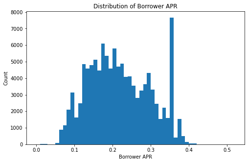

## Distribution of Loan Original Amount

The original loan amount distribution shows that there are a number of high and low spikes. The high spikes include;

2k, 3k, 4k, 5k, 10k, 15k, 20k and 25k

The low spikes include;

6k, 7k, 12k, 13k, 14k, 17k, 35k and many others

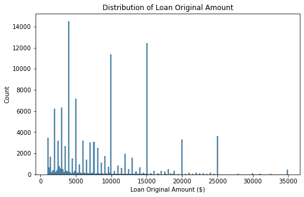

## Borrower APR vs Loan Amount

Plotting the Borrower APR against the Loan Amount indicates that there is a negative linear correlation between Borrower APR and Loan Amount. The more there is an increase in the Loan Amount, the lower the APR is for the borrower.

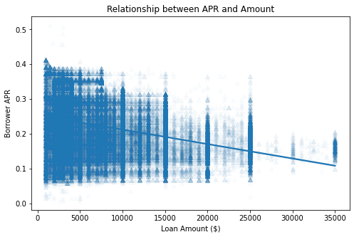

There is a negative relationship between borrower APR and prosper rating. That means the better the rating, the lower the APR.

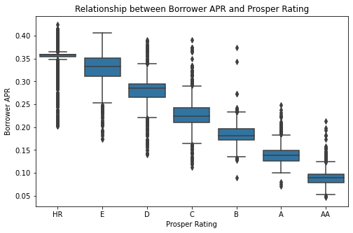

## Prosper Rating and Term vs Monthly Income and Loan Amount

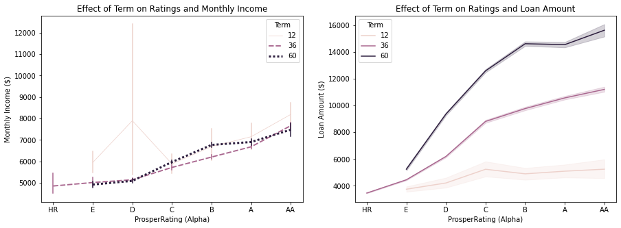